(zurichseede)=

# Zurichsee

English

**Unten:** Karte des Erhebungsgebiets März 2020 - Mai 2021. Durchmesser der Punktsymbole = das mittlere Erhebungsergebnis in gefundene Abfallobjekte pro 100 Meter (p/100m).

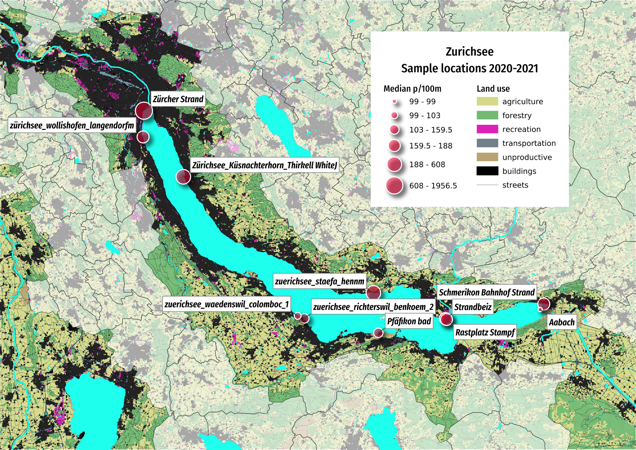

## Erhebungsorte

*Die Gemeinden in diesem Bericht:*

> Freienbach, Küsnacht (ZH), Rapperswil-Jona, Richterswil, Schmerikon, Stäfa, Zürich

### Kumulative Gesamtmengen nach Gemeinden

**Unten:** Zurichsee: kumulierten Gewichte und Maße für die Gemeinden

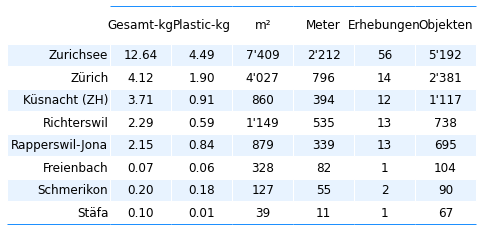

### Verteilung der Datenerhebungen Ergebnisse

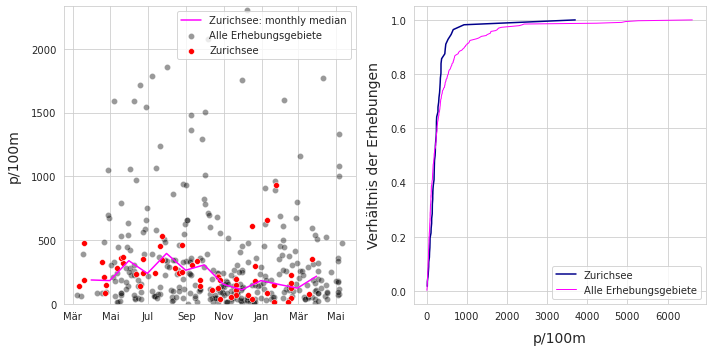

### Zusammenfassende Daten und Materialtypen

**Links:** Zusammenfassung der Daten aller Erhebungen im Zurichsee. **Rechts:** Gefundene Materialarten im Zurichsee und Prozentsatz deren Gesamtmenge.

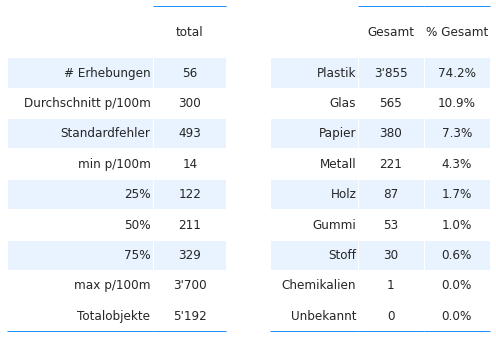

## Die am häufigsten gefundenen Objekte

Die am häufigsten gefundenen Objekte sind die zehn mengenmäßig am meisten vorkommenden Objekte UND/ODER Objekte, die in mindestens 50% aller Datenerhebungen identifiziert wurden (fail-rate).

**Unten:** Häufigste Objekte im Zurichsee: fail-rate >/= 50% und/oder Top Ten nach Anzahl. Zusammengenommen machen die häufigsten Objekte 65% aller gefundenen Objekte aus. Anmerkung: p/100m = Medianwert der Erhebung.

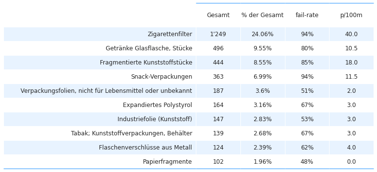

### Die am häufigsten gefundenen Objekte nach Gemeinden

**Unten:** häufigste Objekte im Zurichsee: Median p/100m.

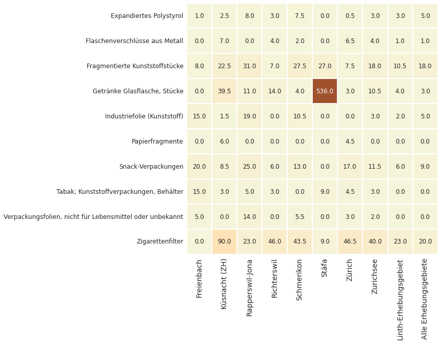

### Die am häufigsten gefundenen Objekte im monatlichen Durchschnitt

**Unten:** Zurichsee, monatliche Durchschnittsergebnisse p/100m.

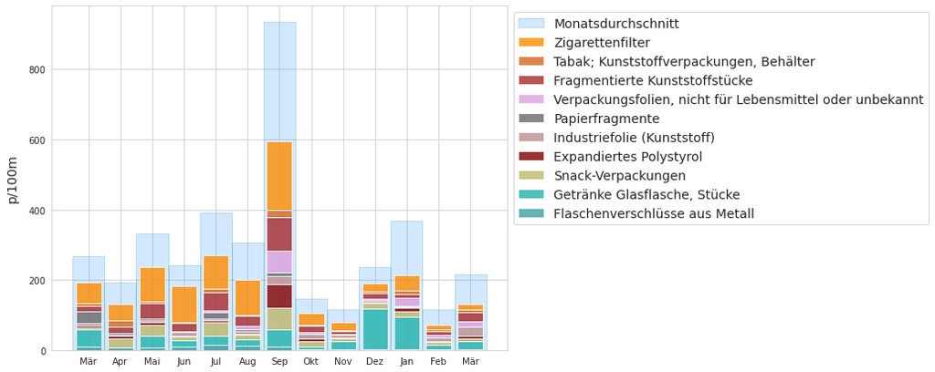

## Verwendungszweck der gefundenen Objekte

Die Nutzungsart basiert auf der Verwendung des Objekts, bevor es weggeworfen wurde, oder auf der Artikelbeschreibung, wenn die ursprüngliche Verwendung unbestimmt ist. Identifizierte Objekte werden einer der 260 vordefinierten Kategorien zugeordnet. Die Kategorien werden je nach Verwendung oder Artikelbeschreibung gruppiert.

- **Abwasser:** Gegenstände, die aus Kläranlagen freigesetzt werden, einschließlich Gegenstände, die wahrscheinlich über die Toilette entsorgt werden
- **Mikroplastik (< 5 mm):** fragmentierte Kunststoffe und Kunststoffharze aus der Vorproduktion
- **Infrastruktur:** Artikel im Zusammenhang mit dem Bau und der Instandhaltung von Gebäuden, Straßen und der Wasser-/Stromversorgung
- **Essen und Trinken:** alle Materialien, die mit dem Konsum von Essen und Trinken in Zusammenhang stehen
- **Landwirtschaft:** z. B. für Mulch und Reihenabdeckungen, Gewächshäuser, Bodenbegasung, Ballenverpackungen. Einschliesslich Hartkunststoffe für landwirtschaftliche Zäune, Blumentöpfe usw.
- **Tabak:** hauptsächlich Zigarettenfilter, einschließlich aller mit dem Rauchen verbundenen Materialien
- **Freizeit und Erholung:** Objekte, die mit Sport und Freizeit zu tun haben, z. B. Angeln, Jagen, Wandern usw.
- **Verpackungen außer Lebensmittel und Getränke:** Verpackungsmaterial, das nicht lebensmittel-, getränke- oder tabakbezogen ist
- **Plastikfragmente:** Plastikteile unbestimmter Herkunft oder Verwendung
- **Persönliche Gegenstände:** Accessoires, Hygieneartikel und Kleidung

Im Anhang finden Sie die vollständige Liste der identifizierten Objekte, einschließlich Beschreibungen und Gruppenklassifizierung. Der Abschnitt Code-Gruppen beschreibt jede Codegruppe im Detail und bietet eine umfassende Liste aller Objekte in einer Gruppe.

**Unten:** Verwendungszweck oder Beschreibung der identifizierten Objekte in % der Gesamtzahl nach Gemeinden im Zurichsee. Fragmentierte Objekte, die nicht eindeutig identifiziert werden können, werden weiterhin nach ihrer Grösse klassifiziert.

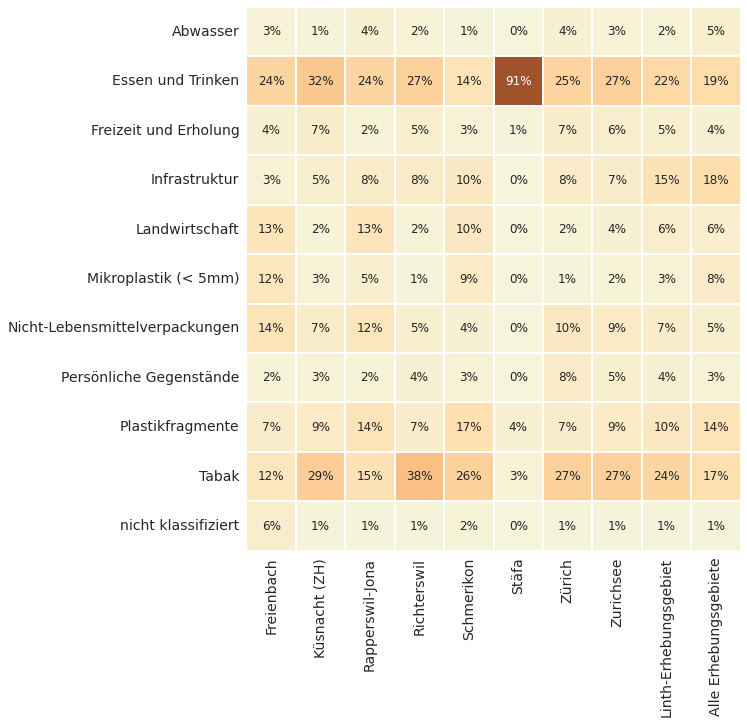

**Unten:** Zurichsee Nutzen der gefundenen Objekte Median p/100m. Fragmentierte Objekte, die nicht eindeutig identifiziert werden können, bleiben nach Größe klassifiziert:

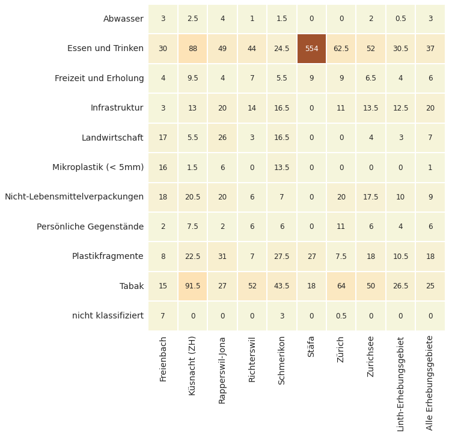

## Anhang

### Schaumstoffe und Kunststoffe nach Größe

Die folgende Tabelle enthält die Komponenten "Gfoam" und "Gfrags", die für die Analyse gruppiert wurden. Objekte, die als Schaumstoffe gekennzeichnet sind, werden als Gfoam gruppiert und umfassen alle geschäumten Polystyrol-Kunststoffe > 0,5 cm. Kunststoffteile und Objekte aus kombinierten Kunststoff- und Schaumstoffmaterialien > 0,5 cm werden für die Analyse als Gfrags gruppiert.

**Unten:** Fragmentierte und geschäumte Kunststoffe nach Größe im Zurichsee, Median p/100m, Anzahl der gefundenen Stücke und Prozent der Gesamtmenge.

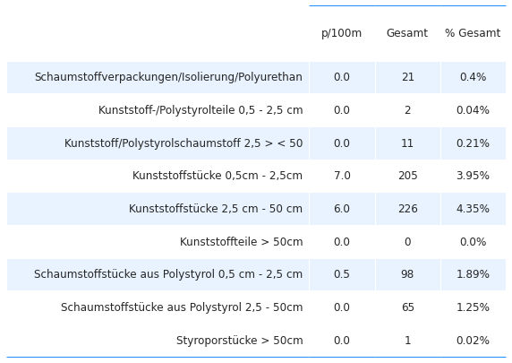

### Die Erhebungsorte

| standort | latitude | longitude | stat |
| --- | --- | --- | --- |
| rastplatz-stampf | 47.215177 | 8.844286 | Rapperswil-Jona |
| zuerichsee_richterswil_benkoem_2 | 47.217646 | 8.698713 | Richterswil |
| pfafikon-bad | 47.206766 | 8.774182 | Freienbach |
| zurichsee_kusnachterhorn_thirkell-whitej | 47.317685 | 8.576860 | Küsnacht (ZH) |
| zurichsee_wollishofen_langendorfm | 47.345890 | 8.536155 | Zürich |
| zurcher-strand | 47.364200 | 8.537420 | Zürich |
| zuerichsee_staefa_hennm | 47.234643 | 8.769881 | Stäfa |
| zuerichsee_waedenswil_colomboc_1 | 47.219547 | 8.691961 | Richterswil |
| schmerikon-bahnhof-strand | 47.224780 | 8.944180 | Schmerikon |
| aabach | 47.220989 | 8.940365 | Schmerikon |
| strandbeiz | 47.215862 | 8.843098 | Rapperswil-Jona |

### Inventar der Objekte

| code | Objekte | Gruppenname | Gesamt | % Gesamt | Ausfallsrate |
| --- | --- | --- | --- | --- | --- |
| G27 | Zigarettenfilter | Tabak | 1249 | 24.06 | 94 |
| G200 | Getränke Glasflasche, Stücke | Essen und Trinken | 496 | 9.55 | 80 |
| Gfrags | Fragmentierte Kunststoffstücke | Plastikfragmente | 444 | 8.55 | 85 |
| G30 | Snack-Verpackungen | Essen und Trinken | 363 | 6.99 | 94 |
| G941 | Verpackungsfolien, nicht für Lebensmittel oder... | Nicht-Lebensmittelverpackungen | 187 | 3.60 | 51 |
| Gfoam | Expandiertes Polystyrol | Infrastruktur | 164 | 3.16 | 67 |
| G67 | Industriefolie (Kunststoff) | Landwirtschaft | 147 | 2.83 | 53 |
| G25 | Tabak; Kunststoffverpackungen, Behälter | Tabak | 139 | 2.68 | 67 |
| G178 | Flaschenverschlüsse aus Metall | Essen und Trinken | 124 | 2.39 | 62 |
| G156 | Papierfragmente | Nicht-Lebensmittelverpackungen | 102 | 1.96 | 48 |
| G73 | Gegenstände aus Schaumstoff & Teilstücke (nich... | Freizeit und Erholung | 87 | 1.68 | 14 |
| G96 | Hygienebinden/Höscheneinlagen/Tampons und Appl... | Abwasser | 82 | 1.58 | 12 |
| G923 | Taschentücher, Toilettenpapier, Servietten, Pa... | Persönliche Gegenstände | 82 | 1.58 | 30 |
| G74 | Schaumstoffverpackungen/Isolierung/Polyurethan | Infrastruktur | 71 | 1.37 | 41 |
| G177 | Verpackungen aus Aluminiumfolie | Essen und Trinken | 66 | 1.27 | 44 |
| G155 | Feuerwerkspapierhülsen und -fragmente | Freizeit und Erholung | 64 | 1.23 | 16 |
| G211 | Sonstiges medizinisches Material | Persönliche Gegenstände | 58 | 1.12 | 33 |
| G112 | Industriepellets (Nurdles) | Mikroplastik (< 5mm) | 52 | 1.00 | 26 |
| G24 | Ringe von Plastikflaschen/Behältern | Essen und Trinken | 51 | 0.98 | 39 |
| G21 | Getränke-Deckel, Getränkeverschluss | Essen und Trinken | 48 | 0.92 | 41 |
| G31 | Schleckstengel, Stengel von Lutscher | Essen und Trinken | 43 | 0.83 | 39 |
| G23 | unidentifizierte Deckel | Nicht-Lebensmittelverpackungen | 42 | 0.81 | 35 |
| G928 | Bänder und Schleifen | Persönliche Gegenstände | 41 | 0.79 | 16 |
| G153 | Papierbecher, Lebensmittelverpackungen aus Pap... | Essen und Trinken | 40 | 0.77 | 30 |
| G904 | Feuerwerkskörper; Raketenkappen | Freizeit und Erholung | 37 | 0.71 | 28 |
| G89 | Kunststoff-Bauabfälle | Infrastruktur | 36 | 0.69 | 37 |
| G148 | Kartonkisten und Stücke | Nicht-Lebensmittelverpackungen | 35 | 0.67 | 19 |
| G159 | Kork | Essen und Trinken | 34 | 0.65 | 23 |
| G95 | Wattestäbchen | Abwasser | 32 | 0.62 | 33 |
| G10 | Lebensmittelbehälter zum einmaligen Gebrauch a... | Essen und Trinken | 28 | 0.54 | 17 |

[output cut: 114 more lines]